# KDD Cup Project

Xiangzhu Long (xiangzhl)

## Introduction

During the last decase, the attack in the network has attracted the attention of many researchers. To prevent these unfriendly visitors, we need to build a network intrusion detector, which can distinguish the ‘’bad’‘connections, and’‘good’’ connections.

## Dataset

This database([KDD Cup 1999 Data](http://archive.ics.uci.edu/ml/machine-learning-databases/kddcup99-mld/kddcup99.html)) contains a standard set of data to be audited, which includes a wide variety of intrusions simulated in a military network environment.

Attacks fall into four main categories:

[output not shown]

## Methods

1. Build different models by using 10% training data;
2. Compare the results of these models;
3. Analysis the first-step result;
4. Make feature engineering;
5. Build new model by using prepocessed features and optimal algorithm on full training dataset;
6. Analysis the result.

## Prediction

### Loading and preprocessing the 10% training data

```r
# Clear the workspace
rm( list = ls() )

# Load the data
train_raw <- read.csv("data/traindata_10percent.csv", stringsAsFactors = FALSE)

# Process the data
colnames <- read.table("data/names", skip = 1, sep = ":")
names(train_raw) <- colnames$V1
d <- dim(train_raw)
names(train_raw)[d[2]] <- "label"

# Observe the data
names(train_raw)
```

[1] “duration” “protocol_type”  
[3] “service” “flag”  
[5] “src_bytes” “dst_bytes”  
[7] “land” “wrong_fragment”  
[9] “urgent” “hot”  
[11] “num_failed_logins” “logged_in”  
[13] “num_compromised” “root_shell”  
[15] “su_attempted” “num_root”  
[17] “num_file_creations” “num_shells”  
[19] “num_access_files” “num_outbound_cmds”  
[21] “is_host_login” “is_guest_login”  
[23] “count” “srv_count”  
[25] “serror_rate” “srv_serror_rate”  
[27] “rerror_rate” “srv_rerror_rate”  
[29] “same_srv_rate” “diff_srv_rate”  
[31] “srv_diff_host_rate” “dst_host_count”  
[33] “dst_host_srv_count” “dst_host_same_srv_rate”  
[35] “dst_host_diff_srv_rate” “dst_host_same_src_port_rate” [37] “dst_host_srv_diff_host_rate” “dst_host_serror_rate”  
[39] “dst_host_srv_serror_rate” “dst_host_rerror_rate”  
[41] “dst_host_srv_rerror_rate” “label”

We can see the 10% kddcup training data has 494020 observations, each data has 41 features and the last one is its label.

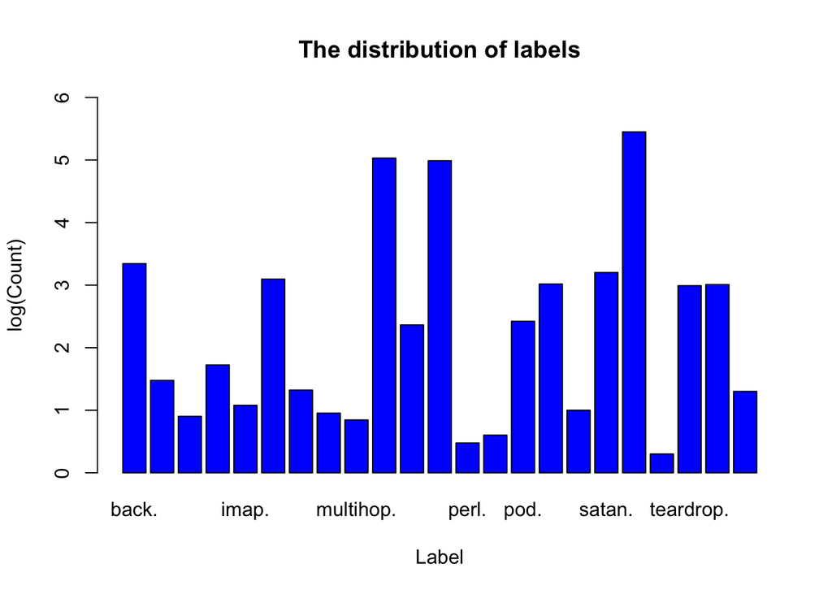

```r
# Observe the distribution of labels.
sum_label <- aggregate(rep(1, d[1]),
                       by = list(train_raw$label),
                       FUN = sum)
names(sum_label) <- c("label", "count")
barplot(beside = TRUE, log10(sum_label$count),
        names.arg = sum_label$label, ylim = c(0,6),
        xlab = "Label", ylab = "log(Count)",
        col = "Blue", main = "The distribution of labels")
```

```r
# Select the features
library(caret)
# Process the feature with NA value.
l <- train_raw$label
sum(is.na(l))
```

```
## [1] 0
```

There is no NA value, which makes our work more simple.

```r
# Clean up near zero variance features
nzvcol <- nearZeroVar(train_raw)
train_raw <- train_raw[, -nzvcol]

#label into factor
training <- train_raw
training$label <- factor(training$label)

d <- dim(training)
```

After preprocessing, the 10% training data has 494020 observations and 19 features.

### Loading and preprocessing the 10% testing data

```r
# Load the data
test_raw <- read.csv("data/testdata_10percent.csv", stringsAsFactors = FALSE)

# Process the data
names(test_raw) <- colnames$V1
names(test_raw)[dim(test_raw)[2]] <- "label"

# Extract the same features as training data
colnames_train <- names(training)
test_raw <- test_raw[ , colnames_train]

testing <- test_raw
testing$label <- as.factor(testing$label)
```

### Building the model by using the Naive Bayes.

```r
library(e1071)

# Build the model
label_result = training[ ,d[2]]
training_data = training[ ,1:(d[2]-1)]
navie_bayes_tree_model = naiveBayes(as.factor(label_result)~.,
                                    training_data)

# Predict the testing
testing_data = testing[ , 1: (d[2]-1)]
navie_bayes_pred = predict(navie_bayes_tree_model, testing_data)
golden_answer = testing[ , d[2]]
navie_bayes_pred = factor(navie_bayes_pred, levels =levels(golden_answer))

# Get the accuracy
NB_accuracy <- mean(golden_answer == navie_bayes_pred,na.rm = TRUE)
```

The accuracy of Naive Bayes is 0.6156518.

### Building the model by using other algorithms.

```r
# Random Forest
library(randomForest)
library(doParallel)

#random seed
set.seed(3433)
#parallel computing for multi-core
registerDoParallel(makeCluster(detectCores()))

model_rf <- train(label ~ .,  method = "rf", data = training)

# Decesion Tree
library(rpart)
decision_tree_model <- rpart(label ~ ., data = training, method = "class")

# Predicting:
decision_tree_pred <- predict(decision_tree_model, testing_data, type = "class")

# Plot of the Decision Tree
rpart.plot(decision_tree_model, main = "Classification Tree",
           extra = 102, under = TRUE, faclen = 0)

# Test results on our subTesting data set:
confusionMatrix(prediction1, subTesting$classe)
```

Actually, it was running without stop. Thus, there is no successful model.

## Analysis the outcome

After make deeper observation and then refer to the article [A Detailed Analysis of the KDD CUP 99 Data Set](http://www.ee.ryerson.ca/~bagheri/papers/cisda.pdf), There exists two issues in the “KDD CUP 99 Data Set”:

1.There are huge number of redundant records.

2.The prediction accuracy is unbelievably high.

```r
# Redundant records in training set
d_train <- dim(train_raw)
d_uniqe_train <- dim(unique(train_raw))
d_train_percent <- (d_train[1] - d_uniqe_train[1]) / d_train[1]
```

In the 10 percent of training dataset, there are 494020 observations, but the number of distinct observations are 110192, which means there are 0.7769483 redundant observations.

```r
# Redundant records in testing set
d_test <- dim(test_raw)
d_uniqe_test <- dim(unique(test_raw))
d_test_percent <- (d_test[1] - d_uniqe_test[1]) / d_test[1]
```

In the 10 percent of testing dataset, there are 311028 observations, but the number of distinct observations are 64873, which means there are 0.7914239 redundant observations.

## Build the naive bayes on full training dataset.

### Loading and preprocessing the full training data

```r
# Clear the workspace
rm( list = ls() )

# Load the data
train_raw <- read.csv("data/traindata_full.csv", stringsAsFactors = FALSE)

# Process the data
colnames <- read.table("data/names", skip = 1, sep = ":")
names(train_raw) <- colnames$V1
d <- dim(train_raw)
names(train_raw)[d[2]] <- "label"
```

We can see the full kddcup training data has 4898430 observations.

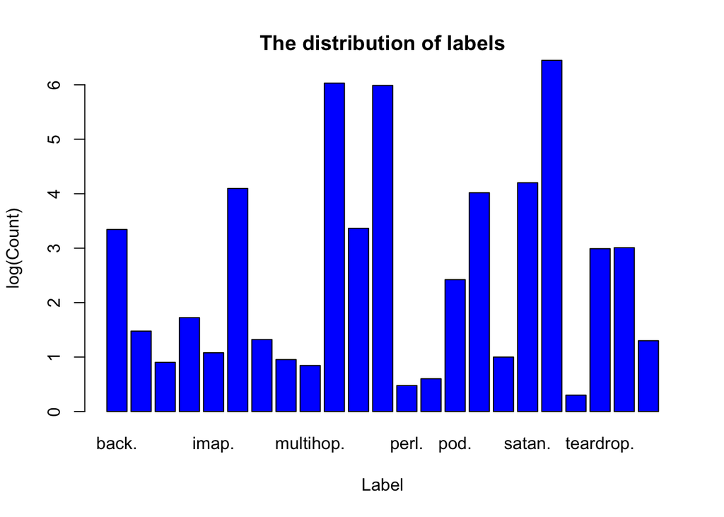

```r
# Observe the distribution of labels.
sum_label <- aggregate(rep(1, d[1]),
                       by = list(train_raw$label),
                       FUN = sum)
names(sum_label) <- c("label", "count")
barplot(beside = TRUE, log10(sum_label$count),
        names.arg = sum_label$label, ylim = c(0,6),
        xlab = "Label", ylab = "log(Count)",
        col = "Blue", main = "The distribution of labels")
```

### Feature Engineering

```r
library(caret)

# Clean up near zero variance features
nzvcol <- nearZeroVar(train_raw)
train_raw <- train_raw[, -nzvcol]

# Delete the duplicate data in the training set.
training_engineer <- unique(train_raw)

d_unique <- dim(training_engineer)
d_percent <- (d[1] - d_unique[1]) / d[1]
```

After removing the duplicate data, the new training dataset contains 587351 observations, which means there are 0.880094 duplicate training data.

```r
d <- d_unique

# Make numeralization.
numeralize <- function(col) {
  # Find the classification of this column.
  char <- unique(col)

  # Change the type to its corresponding type.
  for (i in 1: length(char)) {
      col <- replace(col, col == char[i], i)
    }

  col
}

# Precess these colums with character class.
training_engineer <- within(training_engineer, {
  protocol_type <- numeralize(protocol_type)
  service <- numeralize(service)
  flag <- numeralize(flag)
  label <- numeralize(label)
  } )

summary(training_engineer)
```

```
##  protocol_type        service              flag
##  Length:587351      Length:587351      Length:587351
##  Class :character   Class :character   Class :character
##  Mode  :character   Mode  :character   Mode  :character
##
##
##
##    src_bytes          logged_in          count         srv_count
##  Min.   :0.00e+00   Min.   :0.0000   Min.   :  0.0   Min.   :  0.00
##  1st Qu.:0.00e+00   1st Qu.:0.0000   1st Qu.:  2.0   1st Qu.:  2.00
##  Median :2.25e+02   Median :1.0000   Median :  9.0   Median :  9.00
##  Mean   :1.01e+04   Mean   :0.6342   Mean   : 56.1   Mean   : 15.41
##  3rd Qu.:3.28e+02   3rd Qu.:1.0000   3rd Qu.: 73.0   3rd Qu.: 18.00
##  Max.   :1.38e+09   Max.   :1.0000   Max.   :511.0   Max.   :511.00
##   serror_rate     srv_serror_rate   rerror_rate      srv_rerror_rate
##  Min.   :0.0000   Min.   :0.0000   Min.   :0.00000   Min.   :0.0000
##  1st Qu.:0.0000   1st Qu.:0.0000   1st Qu.:0.00000   1st Qu.:0.0000
##  Median :0.0000   Median :0.0000   Median :0.00000   Median :0.0000
##  Mean   :0.1924   Mean   :0.1936   Mean   :0.08551   Mean   :0.0851
##  3rd Qu.:0.0000   3rd Qu.:0.0000   3rd Qu.:0.00000   3rd Qu.:0.0000
##  Max.   :1.0000   Max.   :1.0000   Max.   :1.00000   Max.   :1.0000
##  diff_srv_rate     dst_host_diff_srv_rate dst_host_same_src_port_rate
##  Min.   :0.00000   Min.   :0.00000        Min.   :0.00000
##  1st Qu.:0.00000   1st Qu.:0.00000        1st Qu.:0.00000
##  Median :0.00000   Median :0.02000        Median :0.01000
##  Mean   :0.04111   Mean   :0.05219        Mean   :0.07992
##  3rd Qu.:0.05000   3rd Qu.:0.07000        3rd Qu.:0.04000
##  Max.   :1.00000   Max.   :1.00000        Max.   :1.00000
##  dst_host_serror_rate dst_host_srv_serror_rate dst_host_rerror_rate
##  Min.   :0.0000       Min.   :0.0000           Min.   :0.00000
##  1st Qu.:0.0000       1st Qu.:0.0000           1st Qu.:0.00000
##  Median :0.0000       Median :0.0000           Median :0.00000
##  Mean   :0.1933       Mean   :0.1924           Mean   :0.08902
##  3rd Qu.:0.0100       3rd Qu.:0.0100           3rd Qu.:0.00000
##  Max.   :1.0000       Max.   :1.0000           Max.   :1.00000
##  dst_host_srv_rerror_rate    label
##  Min.   :0.00000          Length:587351
##  1st Qu.:0.00000          Class :character
##  Median :0.00000          Mode  :character
##  Mean   :0.08919
##  3rd Qu.:0.00000
##  Max.   :1.00000
```

### Loading and preprocessing the testing data

```r
# Load the data
test_raw <- read.csv("data/testdata_10percent.csv", stringsAsFactors = FALSE)

# Process the data
names(test_raw) <- colnames$V1
names(test_raw)[dim(test_raw)[2]] <- "label"

# Extract the same features as training data
colnames_train <- names(training_engineer)
test_raw <- test_raw[ , colnames_train]

# Implement the numeralization feature engineering on testing dataset.
# Note: we could not delete the duplicate data in testing set.
testing_engineer <- within(test_raw, {
  protocol_type <- numeralize(protocol_type)
  service <- numeralize(service)
  flag <- numeralize(flag)
  label <- numeralize(label)
  } )
```

### Build the model and make prediction.

```r
# Build the model
label_result = training_engineer[ ,d[2]]
training_data = training_engineer[ ,1:(d[2]-1)]
navie_bayes_tree_model = naiveBayes(label_result~.,
                                    training_data)

# Predict the testing
testing_data = testing_engineer[, 1: (d[2]-1)]
navie_bayes_pred = predict(navie_bayes_tree_model, testing_data)
golden_answer = testing_engineer[, d[2]]
navie_bayes_pred = factor(navie_bayes_pred, levels =levels(golden_answer))

# Get the accuracy
NB_accuracy <- mean(golden_answer == navie_bayes_pred,na.rm = FALSE)
```

## Future Work

There is still lots more to work on.

1.Implement cross validation to make better prediction of data.

2.Take the prediction and call into consideration to better evaluate the model.